# Allhomework

Weiqi Yang

2021-12-17

##Homework 1

## Question

Use knitr to produce at least 3 examples (texts, figures, tables)

## 文本

以下三个部分为本次作业，这一部分为生成一段文本

## 图像

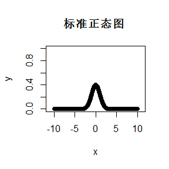

```r
x=seq(-10,10,0.01)
plot(x,exp(((-1/2)*x^2))/sqrt(2*pi),xlim=c(-11,11), ylim=c(0,1), main="标准正态图 ",
xlab="x", ylab="y")
```

## 表格

```r
x <- c(1,2,3,4)
y <-c(2,3,4,5)
x_html=knitr::kable((rbind(x,y)),"html")
kableExtra::kable_styling(x_html,bootstrap_options = "hover",full_width = TRUE,font_size=12)
```

| x | 1 | 2 | 3 | 4 |
| --- | --- | --- | --- | --- |
| y | 2 | 3 | 4 | 5 |

##Homework 2

##3.4 Question： The Rayleigh density [156, Ch. 18] is$f(x)=\frac{x}{\sigma ^{2}}e^{-\frac{x^{2}}{2\sigma ^{2}}},x\geqslant 0,\sigma >0.$ Develop an algorithm to generate random samples from a Rayleigh($\sigma$) distribution. Generate Rayleigh($\sigma$) samples for several choices of $\sigma$> 0 and check that the mode of the generated samples is close to the theoretical mode $\sigma$ (check the histogram).

Answer:

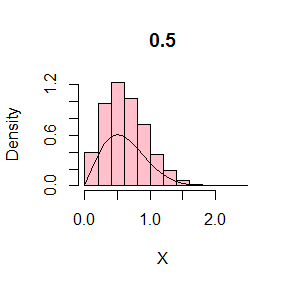

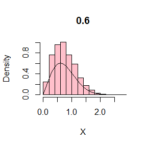

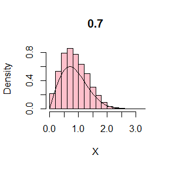

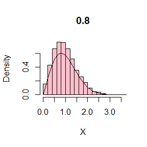

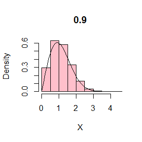

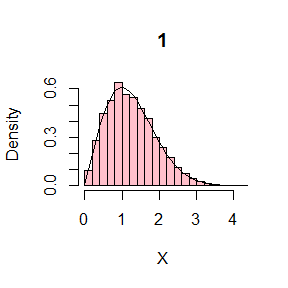

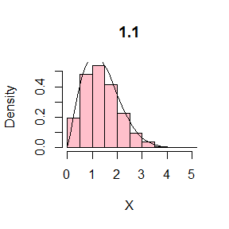

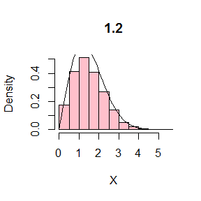

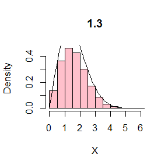

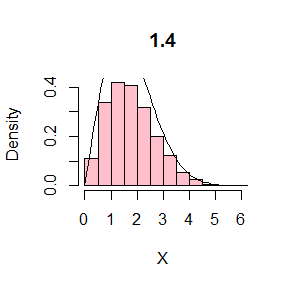

```r
set.seed(123)
Ray=function(sigma,n){
  U=runif(n)
  X=sqrt(-2*sigma^2*log(1-U))

  hist(X,probability = TRUE,col="pink",main=sigma)
  y=seq(0,10,0.1)
  lines(y,(y/sigma)*exp(-y^2/(2*sigma^2)))

  }
par(mfrow=c(1,1))
for(i in seq(0.5,1.4,0.1)){Ray(i,10000)}
```

## 3.11

Question: Generate a random sample of size 1000 from a normal location mixture. The components of the mixture have N(0, 1) and N(3, 1) distributions with mixing probabilities $p_1$ and $p_2$ = 1 −$p_1$. Graph the histogram of the sample with density superimposed, for $p_1$= 0.75. Repeat with different values for p1 and observe whether the empirical distribution of the mixture appears to be bimodal. Make a conjecture about the values of p1 that produce bimodal mixtures.

Answer:

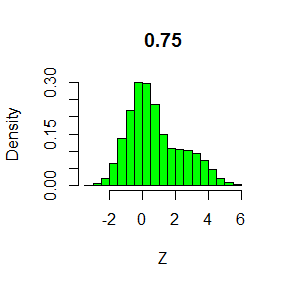

```r
set.seed(1234)
mix=function(p1){
n <- 1e4
X1 <- rnorm(n)
X2 <- rnorm(n,mean=3)
r <- sample(c(0,1),n,replace=TRUE,prob=c(1-p1,p1))
Z <- r*X1+(1-r)*X2
hist(Z,probability = TRUE,col="Green",main=p1)
}
mix(0.75)
```

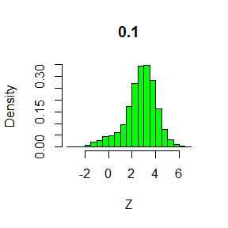

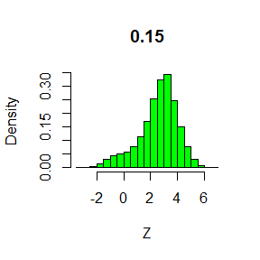

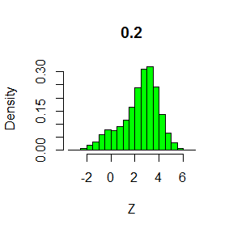

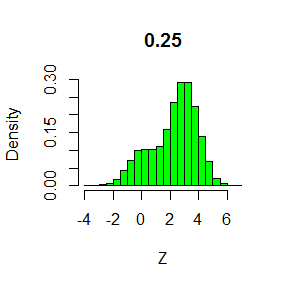

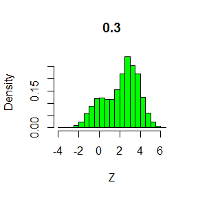

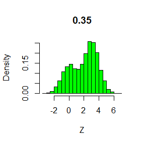

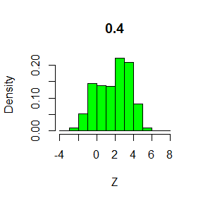

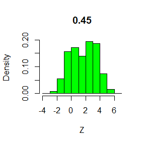

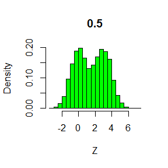

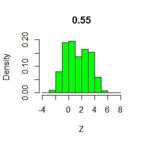

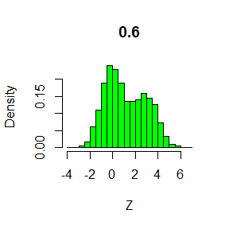

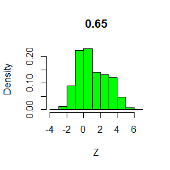

[5 more figures not shown]

```r
par(mfrow=c(1,1))
for(i in seq(0.1,0.9,0.05)){mix(i)}
```

##3.20 Question: A compound Poisson process is a stochastic process $\left \{ X(t),t\geqslant 0 \right \}$ that can be represented as the random sum $X(t)=\sum\limits_{i=1}^{N(t)}Y_i,t\geqslant 0,$ where $\left \{ N(t),t\geqslant 0 \right \}$is a Poisson process and $Y_1,Y_2 \cdot \cdot \cdot$are iid and independent of $\left \{ N(t),t\geqslant 0 \right \}$Write a program to simulate a compound Poisson($\lambda$)–Gamma process (Y has a Gamma distribution). Estimate the mean and the variance of $X(10)$ for several choices of the parameters and compare with the theoretical values.

Answer:

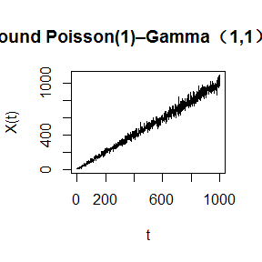

```r
set.seed(12345)

PGprocess=function(n,lamda,shape,size){
X=numeric(n)
for(t in 1:n){
  N=rpois(1,lambda=lamda*t)
  y=rgamma(N,shape,size)
  X[t]=sum(y)}
  return(X)
}
x1000=PGprocess(1000,1,1,1)
plot(1:1000,x1000,xlab="t",ylab="X(t)",main="compound Poisson(1)–Gamma（1,1） process",type="l")
```

Set t=10. Theoretically,
$$E(X(10))=E\left [ E(\sum\limits_{i=1}^{N(10)}Y_i) |N(10)\right ]=E\left [ EY_1\times N(10) \right ]=10\lambda EY_1$$
$$E(X^2(10))=E\left [ E(\sum\limits_{i=1}^{N(10)}Y_i)^2 |N(10)\right ]=E\left [ EY^2_1\times N(10)+ N(10)(N(10)-1)\times (EY_1)^2\right ]=10\lambda EY^2_1+100\lambda ^2(EY_1)^2$$
$$Var(X(10))=EX^2(10)-(EX(10))^2=10\lambda EY^2_1$$
Now we use our program to estimate the mean and variance of the $X(10)$, and compare the results with the thoretical results.

```r
PG10=function(lamda,shape,size){
  N=rpois(10000,lambda=lamda*10)
  x10=numeric(10000)
  for(i in 1:10000){y=rgamma(N[i],shape,size)
  x10[i]=sum(y)}

  est.mean=mean(x10)
  est.var=var(x10)
  real.mean=10*lamda*shape/size
  real.var=10*lamda*((shape/size)^2+shape/(size^2))
  res=array(c(est.mean,est.var,real.mean,real.var),dim=c(2,2))
  dimnames(res)[[1]]=c("est.mean","est.var")
  dimnames(res)[[2]]=c("real.mean","real.var")
  print(res)}
for(i in 1:3){PG10(i,1,1)} ##固定Gamma(1,1),possion参数从1取到3.
```

```
##          real.mean real.var
## est.mean  9.976734       10
## est.var  20.149251       20
##          real.mean real.var
## est.mean  19.95703       20
## est.var   38.76764       40
##          real.mean real.var
## est.mean  30.10715       30
## est.var   59.81180       60
```

```r
for(i in 1:3){PG10(i,1/2,2)} ##固定Gamma(1/2,2),possion参数从1取到3.
```

```
##          real.mean real.var
## est.mean  2.510436    2.500
## est.var   1.891877    1.875
##          real.mean real.var
## est.mean  4.991758     5.00
## est.var   3.743048     3.75
##          real.mean real.var
## est.mean  7.509979    7.500
## est.var   5.565428    5.625
```

```r
for(i in 1:3){PG10(i,2,2)} ##固定Gamma(2,2),possion参数从1取到3.
```

```
##          real.mean real.var
## est.mean  10.03661       10
## est.var   15.08539       15
##          real.mean real.var
## est.mean  19.99262       20
## est.var   30.13939       30
##          real.mean real.var
## est.mean  29.99171       30
## est.var   45.66874       45
```

```r
for(i in 1:3){PG10(i,3,3)} ##固定Gamma(3,3),possion参数从1取到3.
```

```
##          real.mean real.var
## est.mean  9.990141 10.00000
## est.var  13.619363 13.33333
##          real.mean real.var
## est.mean  20.07476 20.00000
## est.var   26.59592 26.66667
##          real.mean real.var
## est.mean  30.00162       30
## est.var   40.37287       40
```

From the tables above, we can see that the estimation of mean and variance is very close to the real mean and variance. Therefore, the simulation is very resonable.

##Homework 3

##5.4

Question:

Write a function to compute a Monte Carlo estimate of the Beta(3, 3) cdf,and use the function to estimate F(x) for x = 0.1, 0.2,…, 0.9. Compare the estimates with the values returned by the pbeta function in R.

Answer:

The detiny function is :$f(x;3,3)=\frac{1}{Beta(3,3)}x^{2}(1-x)^{2},x\in (0,1),$ and $Beta(3,3)=\int_{0}^{1}x^{2}(1-x)^2=1/30$, so it can be simplified as $f(x;3,3)=30x^{2}(1-x)^{2},x\in (0,1).$ Then CDF can be written as $F(x)=\int_{0}^{x}30t^{2}(1-t)^{2}dt.$The following is the program estimating this CDF:

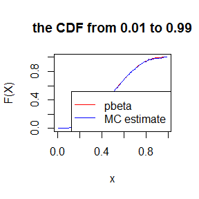

```r
set.seed(1234)
CDF=function(x,n,alpha,beta){
  z=runif(n,0,x)
  y=30*z^(alpha-1)*(1-z)^(beta-1)*x
  cdf.x=mean(y)
  return(cdf.x)
}
cdf=numeric(99)
for(i in seq(0.01,0.99,0.01)){cdf[100*i]=CDF(i,10000,3,3)}
plot(seq(0.01,0.99,0.01),pbeta(seq(0.01,0.99,0.01),3,3),main="the CDF from 0.01 to 0.99",xlab="x",ylab="F(X)",type="l",col="red")
lines(seq(0.01,0.99,0.01),cdf,col="blue")
legend("bottomright", c("pbeta", "MC estimate"), pch = "", col=c("red", "blue"), lwd = 1)
```

```r
MC=numeric(9)
for(i in seq(0.1,0.9,0.1)){MC[10*i]=CDF(i,10000,3,3)}
X=seq(0.1,0.9,0.1)
pbeta=pbeta(seq(0.1,0.9,0.1),3,3)
library(kableExtra)
x_html=knitr::kable((rbind(X,pbeta,MC)),"html")
kableExtra::kable_styling(x_html,bootstrap_options = "hover",full_width = TRUE,font_size=12)#set the size of words in the table
```

| X | 0.1000000 | 0.2000000 | 0.300000 | 0.400000 | 0.500000 | 0.6000000 | 0.7000000 | 0.8000000 | 0.9000000 |
| --- | --- | --- | --- | --- | --- | --- | --- | --- | --- |
| pbeta | 0.0085600 | 0.0579200 | 0.163080 | 0.317440 | 0.500000 | 0.6825600 | 0.8369200 | 0.9420800 | 0.9914400 |
| MC | 0.0085044 | 0.0580415 | 0.162408 | 0.316848 | 0.500626 | 0.6823244 | 0.8347652 | 0.9416167 | 0.9802249 |

The picture and the table both show that the MC extinmation is very close to pbeta.

##5.9

Question:

The Rayleigh density [156, (18.76)] is $f(x)=\frac{x}{\sigma ^2}e^{-x^2/(2\sigma ^2)},x\geqslant 0,\sigma > 0.$ Implement a function to generate samples from a Rayleigh($\sigma$) distribution, using antithetic variables. What is the percent reduction in variance of $\frac{X+X'}{2}$compared with $\frac{X_1+X_2}{2}$ for independent $X_1,X_2$?

Answer:

According to destiny function, the CDF can be written as: $F(x)=1-e^{\frac{x^2}{2\sigma^2}},$ then the inverse function can be wirtten as: $F^{-1}(x)=\sigma \sqrt{-2ln(1-y)}.$ Now we use the antithetic variables and indepandent variables to generate the $\frac{X_1+X_2}{2}$, and campare their vairances($\sigma$ is set from 1 to 10).

```r
set.seed(123)
Ray = function(sig=sigma,R = 10000, antithetic = TRUE) {
  u = runif(R)
  if (!antithetic){
  v=runif(R)
  x1=sig*sqrt(-2*log(1-u))
  x2=sig*sqrt(-2*log(1-v))

  ray=(x1+x2)/2
  }
  else{
  v = 1 - u
  x1=sig*sqrt(-2*log(1-u))
  x2=sig*sqrt(-2*log(1-v))
  ray=(x1+x2)/2
  }

  return(ray)
}

sd.norm=numeric(10)
for(i in 1:10){ray.norm=Ray(sig=i,R = 10000,antithetic = FALSE)
sd.norm[i]=var(ray.norm)}
sd.anti=numeric(10)
for(i in 1:10){ray.anti=Ray(sig=i,R = 10000,antithetic = TRUE)
sd.anti[i]=var(ray.anti)}
library(kableExtra)
sigma=1:10
percent.reduction=(sd.norm-sd.anti)/sd.norm
x_html=knitr::kable((rbind(sigma,sd.norm,sd.anti,percent.reduction)),"html")
kableExtra::kable_styling(x_html,bootstrap_options = "hover",full_width = TRUE,font_size=12)#set the size of words in the table
```

| sigma | 1.0000000 | 2.0000000 | 3.0000000 | 4.0000000 | 5.0000000 | 6.0000000 | 7.0000000 | 8.0000000 | 9.0000000 | 10.0000000 |
| --- | --- | --- | --- | --- | --- | --- | --- | --- | --- | --- |
| sd.norm | 0.2076302 | 0.8470604 | 1.9553254 | 3.4344923 | 5.2444756 | 7.7557944 | 10.3163717 | 13.9114006 | 17.4469841 | 20.9334281 |
| sd.anti | 0.0122267 | 0.0481467 | 0.0939289 | 0.1826333 | 0.2757918 | 0.4137229 | 0.5816343 | 0.7445564 | 0.8974578 | 1.1509044 |
| percent.reduction | 0.9411133 | 0.9431602 | 0.9519625 | 0.9468238 | 0.9474129 | 0.9466563 | 0.9436203 | 0.9464787 | 0.9485609 | 0.9450207 |

According to the table, we can find that the antithetic variables method can largely reduce the variance, and the percent of reduction is near 0.945.

##5.13

Question:

Find two importance functions f1 and f2 that are supported on $(1,\infty)$ and are ‘close’ to $g(x)=\frac{x^2}{\sqrt{2\pi }}e^{-\frac{x^2}{2}},x>1.$Which of your two importance functions should produce the smaller variance in estimating $\int_{1}^{\infty }\frac{x^2}{\sqrt{2\pi }}e^{-\frac{x^2}{2}}dx$ by importance sampling? Explain.

Answer:

Since $\frac{1}{\sqrt{2\pi }}e^{-\frac{x^2}{2}}$ is the destiny function of standard normal distribution, $\int_{-\infty}^{\infty }\frac{x^2}{\sqrt{2\pi }}e^{-\frac{x^2}{2}}dx=EX^2(X\sim N(0,1))=1$. Because of symmetry, $\int_{0}^{\infty }\frac{x^2}{\sqrt{2\pi }}e^{-\frac{x^2}{2}}dx=0.5,$ then $\int_{1}^{\infty }\frac{x^2}{\sqrt{2\pi }}e^{-\frac{x^2}{2}}dx=0.5-\int_{0}^{1}\frac{x^2}{\sqrt{2\pi }}e^{-\frac{x^2}{2}}dx$ . Therefore, we only need to estimate $\int_{0}^{1}\frac{x^2}{\sqrt{2\pi }}e^{-\frac{x^2}{2}}dx.$

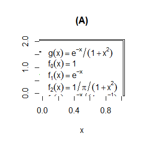

```r
    x <- seq(0, 1, .01)
    w <- 2

    g <- x^2*exp(-x^2/2) / sqrt(2*pi)
    f0 <- rep(1,length(x))
    f1 <- exp(-x)
    f2 <- (1 / pi) / (1 + x^2)
    f3 <- exp(-x) / (1 - exp(-1))
    f4 <- 4 / ((1 + x^2) * pi)
    gs <- c(expression(g(x)==e^{-x}/(1+x^2)),
            expression(f[0](x)==1),
            expression(f[1](x)==e^{-x}),
            expression(f[2](x)==1/pi/(1+x^2)),
            expression(f[3](x)==e^{-x}/(1-e^{-1})),
            expression(f[4](x)==4/((1+x^2)*pi)))
    #for color change lty to col
    par(mfrow=c(1,1))
    #figure (a)
    plot(x, g, type = "l", ylab = "",
         ylim = c(0,2), lwd = w,col=1,main='(A)')
    lines(x, f0, lty = 2, lwd = w,col=2)
    lines(x, f1, lty = 3, lwd = w,col=3)
    lines(x, f2, lty = 4, lwd = w,col=4)
    lines(x, f3, lty = 5, lwd = w,col=5)
    lines(x, f4, lty = 6, lwd = w,col=6)
    legend("topright", legend = gs,
           lty = 1:6, lwd = w, inset = 0.02,col=1:6)
```

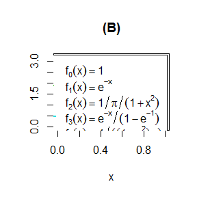

```r
    #figure (b)
    plot(x, g/f0, type = "l", ylab = "",
        ylim = c(0,3.2), lwd = w, lty = 2,col=2,main='(B)')
    lines(x, g/f1, lty = 3, lwd = w,col=3)
    lines(x, g/f2, lty = 4, lwd = w,col=4)
    lines(x, g/f3, lty = 5, lwd = w,col=5)
    lines(x, g/f4, lty = 6, lwd = w,col=6)
    legend("topright", legend = gs[-1],
           lty = 2:6, lwd = w, inset = 0.02,col=2:6)
```

In the picture, we compare $g$ with $f_0...f_4$. Then we use them as importance functions to estimate $\int_{0}^{1}\frac{x^2}{\sqrt{2\pi }}e^{-\frac{x^2}{2}}dx.$

```r
set.seed(123)
  m <- 10000
  est <- sd <- numeric(5)
  g <- function(x) {
  x^2*exp(-x^2/2) / sqrt(2*pi) * (x > 0) * (x < 1)
  }
  x <- runif(m) #using f0
  fg <- g(x)
  est[1] <- mean(fg)
  sd[1] <- sd(fg)
  x <- rexp(m, 1) #using f1
  fg <- g(x) / exp(-x)
  est[2] <- mean(fg)
  sd[2] <- sd(fg)
  x <- rcauchy(m) #using f2
  i <- c(which(x > 1), which(x < 0))
  x[i] <- 2 #to catch overflow errors in g(x)
  fg <- g(x) / dcauchy(x)
  est[3] <- mean(fg)
  sd[3] <- sd(fg)
  u <- runif(m) #f3, inverse transform method
  x <- - log(1 - u * (1 - exp(-1)))
  fg <- g(x) / (exp(-x) / (1 - exp(-1)))
  est[4] <- mean(fg)
  sd[4] <- sd(fg)
  u <- runif(m) #f4, inverse transform method
  x <- tan(pi * u / 4)
  fg <- g(x) / (4 / ((1 + x^2) * pi))
  est[5] <- mean(fg)
  sd[5] <- sd(fg)
  est.real=0.5-est
x_html=knitr::kable((cbind(est.real,sd)),"html")
kableExtra::kable_styling(x_html,bootstrap_options = "hover",full_width = TRUE,font_size=12)
```

| est.real | sd |
| --- | --- |
| 0.4014014 | 0.0773941 |
| 0.3980756 | 0.1635137 |
| 0.3998035 | 0.2690982 |
| 0.4009762 | 0.1134555 |
| 0.3996563 | 0.1056249 |

According to the result ablove, we use $f_0(x)=1,f_4(x)=\frac{4}{\pi(1+x^2)}$ as the importance function, for their lower variance. And the estimation(est.real) based on these two is shown in the table.

##5.14

Question:

Obtain a Monte Carlo estimate of
$$\int_{1}^{\infty }\frac{x^2}{\sqrt{2\pi }}e^{-\frac{x^2}{2}}dx$$

by importance sampling.

Answer:

In 5.13, we have already estimated $\int_{1}^{\infty}\frac{x^2}{\sqrt{2\pi }}e^{-\frac{x^2}{2}}dx.$ The result is shown in the table.

```r
set.seed(123)
  m <- 10000
  est <- sd <- numeric(5)
  g <- function(x) {
  x^2*exp(-x^2/2) / sqrt(2*pi) * (x > 0) * (x < 1)
  }
  x <- runif(m) #using f0
  fg <- g(x)
  est[1] <- mean(fg)
  sd[1] <- sd(fg)
  x <- rexp(m, 1) #using f1
  fg <- g(x) / exp(-x)
  est[2] <- mean(fg)
  sd[2] <- sd(fg)
  x <- rcauchy(m) #using f2
  i <- c(which(x > 1), which(x < 0))
  x[i] <- 2 #to catch overflow errors in g(x)
  fg <- g(x) / dcauchy(x)
  est[3] <- mean(fg)
  sd[3] <- sd(fg)
  u <- runif(m) #f3, inverse transform method
  x <- - log(1 - u * (1 - exp(-1)))
  fg <- g(x) / (exp(-x) / (1 - exp(-1)))
  est[4] <- mean(fg)
  sd[4] <- sd(fg)
  u <- runif(m) #f4, inverse transform method
  x <- tan(pi * u / 4)
  fg <- g(x) / (4 / ((1 + x^2) * pi))
  est[5] <- mean(fg)
  sd[5] <- sd(fg)
  est.real=0.5-est
x_html=knitr::kable((cbind(est.real,sd)),"html")
kableExtra::kable_styling(x_html,bootstrap_options = "hover",full_width = TRUE,font_size=12)
```

| est.real | sd |
| --- | --- |
| 0.4014014 | 0.0773941 |
| 0.3980756 | 0.1635137 |
| 0.3998035 | 0.2690982 |
| 0.4009762 | 0.1134555 |
| 0.3996563 | 0.1056249 |

The est.real is the result.

##Homework 4

## 6.5

Question:

Suppose a $95\%$ symmetric $t$-interval is applied to estimate a mean, but the sample data are non-normal. Then the probability that the confidence interval covers the mean is not necessarily equal to 0.95. Use a Monte Carlo experiment to estimate the coverage probability of the t-interval for random samples of $\chi ^2(2)$ data with sample size n = 20. Compare your t-interval results with the simulation results in Example 6.4. (The $t$-interval should be more robust to departures from normality than the interval for variance.)

Answer:

First, we generate the sample ($X_1...X_n\sim\chi ^2(2),$) so the $EX=2$. Then we generate the corresponding $t$-interval($\left [ \bar{X}-\sqrt{\frac{S^{2}}{n}}t_{n-1}(1-0.25),\bar{X}+\sqrt{\frac{S^{2}}{n}}t_{n-1}(1-0.25) \right ]$), and repeat this experiment $m=100000$ times to estimate the probability of the coverage of $EX$.

```r
set.seed(123)
np=0
for(i in 1:100000){
  x=rchisq(20,2)
  if(abs(mean(x)-2)<sqrt(var(x)/length(x))*qt(0.975,(length(x)-1))){np=np+1}
}
p=np/100000
p
```

```
## [1] 0.91982
```

We can find that the probability of coverage is not equal to $0.95,$ which shows that in the small sample, the $t$-interval is not as good as expected. However it can still work.

Then use the method in $Example~6.4$ to estimate the variance($Var(X)=2\times2=4$). The one side ($95\%$)interval is $\left ( 0,\frac{(n-1)S^2}{\chi _{n-1}^2(0.95)} \right )$, we repeat the experiment $m=100000$ times to estimate the probability of the coverage of $Var(X)$.

```r
set.seed(123)
np=0
for(i in 1:100000){
  x=rchisq(20,2)
  if(4<(length(x)-1)*var(x)/qchisq(0.95,(length(x)-1))){np=np+1}
}
p=np/100000
p
```

```
## [1] 0.13937
```

We can find that the probability of coverage is extremely small, compared with $t$-interval. Therefore, we can draw a conclusion that the $t$-method is more robust.

##6.A

Question:

Use Monte Carlo simulation to investigate whether the empirical Type I error rate of the $t$-test is approximately equal to the nominal significance level $\alpha$, when the sampled population is non-normal. The t-test is robust to mild departures from normality. Discuss the simulation results for the cases where the sampled population is $(i)$ $\chi^2(1)$, (ii) Uniform(0,2), and (iii) Exponential(rate=1). In each case, test
$$H_0 : \mu = \mu_0 ~vs~ H_1 :\mu \not= \mu_0,$$
where $\mu_0$ is the mean of $\chi^2(1)$, Uniform(0,2), and Exponential(1), respectively.

Answer:

```r
set.seed(12)
n=100
m=10000
alpha=0.05
mu0=1
p1=numeric(m)
p2=numeric(m)
p3=numeric(m)
for(i in 1:m){
  x1=rchisq(n,1)
  x2=runif(n,0,2)
  x3=rexp(n)
  ttest1 <- t.test(x1, alternative = "two.sided", mu = mu0,conf.level = 1-alpha)
  ttest2 <- t.test(x2, alternative = "two.sided", mu = mu0,conf.level = 1-alpha)
  ttest3 <- t.test(x3, alternative = "two.sided", mu = mu0,conf.level = 1-alpha)
  p1[i]=ttest1$p.value
  p2[i]=ttest2$p.value
  p3[i]=ttest3$p.value
}
Ierror.chisq=mean(p1<alpha)
Ierror.unif=mean(p2<alpha)
Ierror.exp=mean(p3<alpha)
x_html=knitr::kable((cbind(Ierror.chisq,Ierror.unif,Ierror.exp)),"html")
kableExtra::kable_styling(x_html,bootstrap_options = "hover",full_width = TRUE,font_size=12)
```

| Ierror.chisq | Ierror.unif | Ierror.exp |
| --- | --- | --- |
| 0.0657 | 0.0468 | 0.0569 |

From the table, we can see that the Type I error rate of these three distributions is very close to $\alpha=0.05$, which supports that the t-test is robust to mild departures from normality.

## The question on PPT

Question:

If we obtain the powers for two methods under a particular simulation setting with 10,000 experiments: say, 0.651 for one method and 0.676 for another method. We want to know if the powers are different at 0.05 level.What is the corresponding hypothesis test problem? What test should we use? Z-test, two-sample t-test, paired-t test or McNemar test? Why? Please provide the least necessary information for hypothesis testing.

Answer:

Suppose $\left \{ p_i,i=1...n,(n=10000) \right \}$ are the p-values of these experiments with method one (,whose power is 0.651); $\left \{ q_i,i=1...n,(n=10000) \right \}$ are the p-values of these experiments with method two (,whose power is 0.676). \ As $\left \{ p_i \right \}$ share the same method, they are from the same population. Set $\left \{ y_i=I_{\left \{ p_i<\alpha\right \}},i =1...n \right \}$, the $y_i \sim B(1,p)$, where $p=P_{H_1}(p-value<\alpha)$( with method one). In fact, the power1(the power of method one) is $\bar{y}$, therefore $n\times power=n\bar{y}\sim B(n,p).$

Similarly, the power2(the power of method twq) is $\bar{y}$, therefore $n\times power1=n\bar{y}\sim B(n,{p}'),$ where ${p}'=P_{H_1}(p-value<\alpha)$( with method two).

Therefore, this question equal to the following question:
$$X\sim B(1,p_1),\left \{ X_i,i=1...n \right \} are~from~X;~Y\sim B(1,p_2),\left \{ Y_i,i=1...n \right \} are~from~Y$$
$$\bar{X}=0.651,\bar{Y}=0.676,~then~test~the~following~hypothesis:$$
$$H_0:p_1=p_2\leftrightarrow H_1:p_1\not=p_2$$
Since the size of sample is very large (,which means asymptotic normality ), we can use $two-sample$ t-test to test this hypothesis, whose statistic is
$$T=\frac{\bar{X}-\bar{Y}-(p_1-p_2)}{\sqrt{\frac{1}{n}+\frac{1}{n}}S_w},~T\sim t(2n-2),the~reject~region~is~ \left \{ |T|>t_\frac{\alpha }{2} (2n-2)\right \}.$$
, where
$$S_w=\frac{1}{n+n-2}\left [ \sum\limits_{i=1}^{n}(X_i-\bar{X})^2+\sum\limits_{i=1}^{n}(Y_i-\bar{Y})^2 \right ]$$
In this problem $S_w=\frac{6510+6760}{20000-2},|T|=2.170115>t_\frac{\alpha }{2} (2n-2)(1.960083),$ therefore reject the null hypothesis, that is these two methods have different powers.

But $two-sample t-test$ needs these two population are independent, which may be not true. Therefore we consider another method $Z-test$, whose statistic is
$$Z=\frac{\bar{X}-\bar{\bar{Y}}-(p_1-p_2)}{\sqrt{\frac{\bar{X}(1-\bar{X})}{n}+\frac{\bar{Y}(1-\bar{Y})}{n}}},Z\overset{F}{\rightarrow}N(0,1),$$
the reject region is $\left \{ |Z|>u_\frac{\alpha }{2} \right \}.$ In this problem,
$$|Z|=3.742519,|Z|>u_{\frac{\alpha}{2}}(1.96),so~reject~H_0.$$
That means these two method have different powers in 0.05 level.

##Homework 5

##6.C

Repeat Examples 6.8 and 6.10 for Mardia’s multivariate skewness test. Mardia [187] proposed tests of multivariate normality based on multivariate generalizations of skewness and kurtosis. If $X$ and $Y$ are iid, the multivariate population skewness $\beta_{1,d}$, is defined by Mardia as
$$\beta _{1,d}=E\left [ \left ( X-\mu \right )^{T}\Sigma ^{-1} \left ( Y-\mu \right )\right ]^{3}$$
Under normality, $\beta_{1,d}=0$. The multivariate skewness statistic is
$$b_{1,b}=\frac{1}{n^{2}}\sum\limits_{i,j=1}^{n}((X_i-\bar{X})^T\Sigma ^{-1}(Y_i-\bar{Y}))^3$$
where $\hat{\Sigma }$ is the maximum likelihood estimator of covariance. Large values of $b_{1,d}$ are significant. The asymptotic distribution of $nb_{1,d}/6$ is chisquared with $d(d + 1)(d + 2)/6$ degrees of freedom.

##Answer

The hypothesis is :
$$H_0:\beta_{1,d}=0\leftrightarrow \beta_{1,d}\not=0.$$
The statistic is
$$b_{1,b}=\frac{1}{n^{2}}\sum\limits_{i,j=1}^{n}((X_i-\bar{X})^T\Sigma ^{-1}(Y_i-\bar{Y}))^3,~nb_{1,b}/6\overset{.}{\rightarrow}\chi ^2(d(d+1)(d+2)/6),~where~d=dimension~of~X$$
Now, we assess the Type I error rate for a skewness test of normality at $\alpha = 0.05$ based on the asymptotic distribution of $b_{1,d}$ for sample sizes $n = 10, 20, 30,50, 100, and~ 500$. And without loss of generality, we set $d=1,2,3$ to repeat this experiment $m=10000$ times respectively.

```r
set.seed(123)
critical=function(d){
  return(qchisq(0.95,df=d*(d+1)*(d+2)/6))
}
cvalue=c(critical(1),critical(2),critical(3))
statis<- function(x) {
  #computes the sample skewness .
  statistic=0
  sigma=cov(x,x)
  n=dim(x)[1]
  d=dim(x)[2]
  mat=(scale(x, center = TRUE, scale = TRUE))%*%t(scale(x, center = TRUE, scale = TRUE))
  statistic=sum(mat^3)
  return( statistic/n/6 )
}
n=c(10,20,30,50,100,500)
m=10000
Ierror=matrix(nrow=length(n),ncol=3)
for(i in 1:length(n)){
  for(d in 1:3){
    result=numeric(m)
    for(j in 1:m){
      x=array(rnorm(n[i]*d),dim=c(n[i],d))
      result[j]=as.integer(abs(statis(x)) >=cvalue[d] )
    }
    Ierror[i,d]=mean(result)
  }
}
dimnames(Ierror)[[1]]=c("size=10","size=20","size=30","size=50","size=100","size=500")
dimnames(Ierror)[[2]]=c("d=1","d=2","d=3")
print(Ierror)
```

```
##             d=1    d=2    d=3
## size=10  0.0039 0.0089 0.0091
## size=20  0.0189 0.0221 0.0250
## size=30  0.0253 0.0323 0.0382
## size=50  0.0344 0.0424 0.0434
## size=100 0.0415 0.0459 0.0498
## size=500 0.0484 0.0489 0.0521
```

These are the the empirical estimates of Type I error rate, we can see that when the size of sample get large, the Type I error rate gets close to nominal level $\alpha=0.05.$

Then, we estimate by simulation the power of the skewness test of normality against a contaminated normal (normal scale mixture) alternative described in Example 6.10. The contaminated normal distribution is denoted by:
$$\left ( 1-\varepsilon \right )N(0,1)+\varepsilon N(0,100)$$
When $\varepsilon = 0 ~or~ \varepsilon = 1$ the distribution is normal, but the mixture is nonnormal for $0 <\varepsilon< 1$. We can estimate the power of the skewness test for a sequence of alternatives indexed by $\varepsilon$ and plot a power curve for the power of the skewness test against this type of alternative. For this experiment, the significance level is $\alpha= 0.05$ and the sample size is $n = 30$, the dimension $d=1，2，3$.

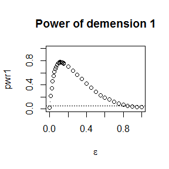

```r
set.seed(12)
alpha <- .1
n <- 30
m <- 2500
epsilon <- c(seq(0, .15, .01), seq(.15, 1, .05))
N <- length(epsilon)
pwr1 <- numeric(N)
pwr2 <- numeric(N)
pwr3<- numeric(N)
critical=function(d){
  return(qchisq(0.95,df=d*(d+1)*(d+2)/6))
}
cvalue=c(critical(1),critical(2),critical(3))
statis<- function(x) {
  #computes the sample skewness .
  statistic=0
  sigma=cov(x,x)
  n=dim(x)[1]
  mat=(scale(x, center = TRUE, scale = TRUE))%*%t(scale(x, center = TRUE, scale = TRUE))
  statistic=sum(mat^3)
  return( statistic/n/6 )
}
for (j in 1:N) { #for each epsilon
 e <- epsilon[j]
 sktests1 <- numeric(m)
  sktests2 <- numeric(m)
   sktests3 <- numeric(m)
 for (i in 1:m) { #for each replicate
 sig1 <- sample(c(1, 10), replace = TRUE,size = n*1, prob = c(1-e, e))
 x=array(rnorm(30*1,0,sig1),dim=c(30,1))
 sktests1[i] <- as.integer(statis(x) >= critical(1))
  sig2 <- sample(c(1, 10), replace = TRUE,size = n*2, prob = c(1-e, e))
 x=array(rnorm(30*2,0,sig2),dim=c(30,2))
 sktests2[i] <- as.integer(statis(x) >= critical(2))
  sig3 <- sample(c(1, 10), replace = TRUE,size = n*3, prob = c(1-e, e))
 x=array(rnorm(30*3,0,sig3),dim=c(30,3))
 sktests3[i] <- as.integer(statis(x) >= critical(3))
}
pwr1[j] <- mean(sktests1)
pwr2[j] <- mean(sktests2)
pwr3[j] <- mean(sktests3)
}
#plot po
plot(epsilon, pwr1, type = "b",
xlab = bquote(epsilon), ylim = c(0,1),main="Power of demension 1")
abline(h = .05, lty = 3)
```

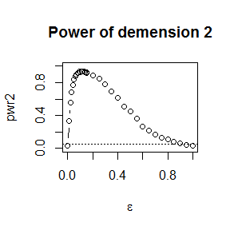

```r
plot(epsilon, pwr2, type = "b",
xlab = bquote(epsilon), ylim = c(0,1),main="Power of demension 2")
abline(h = .05, lty = 3)
```

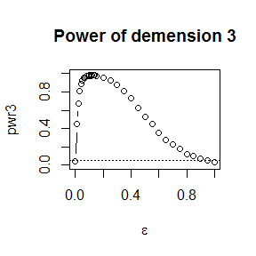

```r
plot(epsilon, pwr3, type = "b",
xlab = bquote(epsilon), ylim = c(0,1),main="Power of demension 3")
abline(h = .05, lty = 3)
```

##Homework 6

##7.7

Refer to Exercise 7.6. Efron and Tibshirani discuss the following example [84,Ch. 7]. The five-dimensional scores data have a$5\times5$ covariance matrix $\Sigma$, with positive eigenvalues $\lambda_1>...\lambda_5$. In principal components analysis,
$$\theta=\frac{\lambda_1}{\sum\limits_{i=1}^{5}\lambda_i}$$
measures the proportion of variance explained by the first principal component. Let$\hat{\lambda_1}>...\hat{\lambda_5}$ be the eigenvalues of $\hat{\Sigma}$, where $\hat{\Sigma}$ is the MLE of $\Sigma$.Compute the sample estimate
$$\hat{\theta}=\frac{\hat{\lambda}_1}{\sum\limits_{i=1}^{5}\hat{\lambda}_i}$$

##Answer

```r
set.seed(123)
library(boot)
library(bootstrap)
lambda_hat <- eigen(cov(scor))$values
theta_hat <- lambda_hat[1] / sum(lambda_hat)
B <-5000
n <- nrow(scor)
func <- function(dat, index){
  x <- dat[index,]
  lambda <- eigen(cov(x))$values
  theta <- lambda[1] / sum(lambda)
  return(theta)
}
bootstrap_result <- boot(
  data = cbind(scor$mec, scor$vec, scor$alg, scor$ana, scor$sta),
  statistic = func, R = B)
theta_b <- bootstrap_result$t
bias_boot <- mean(theta_b) - theta_hat
se_boot <- sd(theta_b)
x_html=knitr::kable((rbind(theta_hat,bias_boot,se_boot)),"html")
kableExtra::kable_styling(x_html,bootstrap_options = "hover",full_width = TRUE,font_size=12)
```

| theta_hat | 0.6191150 |
| --- | --- |
| bias_boot | 0.0014092 |
| se_boot | 0.0469757 |

##7.8

Refer to Exercise 7.7. Obtain the jackknife estimates of bias and standard error of $\bar{\theta}$.

## Answer

```r
theta_j <- rep(0, n)
for (i in 1:n) {
  x <- scor [-i,]
  lambda <- eigen(cov(x))$values
  theta_j[i] <- lambda[1] / sum(lambda)
}
bias_jack <- (n - 1) * (mean(theta_j) - theta_hat)
se_jack <- (n - 1) * sqrt(var(theta_j) / n)
x_html=knitr::kable((rbind(bias_jack,se_jack)),"html")
kableExtra::kable_styling(x_html,bootstrap_options = "hover",full_width = TRUE,font_size=12)
```

| bias_jack | 0.0010691 |
| --- | --- |
| se_jack | 0.0495523 |

##7.9

Refer to Exercise 7.7. Compute $95\%$ percentile and $BC_a$ confidence intervals for $\bar{\theta}$.

##Answer

```r
set.seed(123)
library(boot)
library(bootstrap)
lambda_hat <- eigen(cov(scor))$values
theta_hat <- lambda_hat[1] / sum(lambda_hat)
B <-5000
n <- nrow(scor)
func <- function(dat, index){
  x <- dat[index,]
  lambda <- eigen(cov(x))$values
  theta <- lambda[1] / sum(lambda)
  return(theta)
}
bootstrap_result <- boot(
  data = cbind(scor$mec, scor$vec, scor$alg, scor$ana, scor$sta),
  statistic = func, R = B)
ci <- boot.ci(bootstrap_result,type=c("norm","basic","perc","bca"))
ci
```

```
## BOOTSTRAP CONFIDENCE INTERVAL CALCULATIONS
## Based on 5000 bootstrap replicates
##
## CALL :
## boot.ci(boot.out = bootstrap_result, type = c("norm", "basic",
##     "perc", "bca"))
##
## Intervals :
## Level      Normal              Basic
## 95%   ( 0.5256,  0.7098 )   ( 0.5312,  0.7141 )
##
## Level     Percentile            BCa
## 95%   ( 0.5242,  0.7070 )   ( 0.5209,  0.7047 )
## Calculations and Intervals on Original Scale
```

##7.B

Repeat Project 7.A for the sample skewness statistic. Compare the coverage rates for normal populations (skewness $0$) and $\chi^2(5)$ distributions (positive skewness).

##Answer

```r
set.seed(1234)
library(boot)
n=100
B=1000

func=function(x,i){
  mu2=var(x[i,])
  mu3=mean((x[i,]-mean(x[i,]))^3)
  skew=mu3/mu2^(3/2)
  return(skew)
}
cvoer.rat.norm=function(n=100,B=1000,m=5000,a){
  cr_norm1 = numeric(m)
  left_norm1 = numeric(m)
  right_norm1 = numeric(m)
  cr_perc1 = numeric(m)
  left_perc1 = numeric(m)
  right_perc1 = numeric(m)
  cr_basic1 = numeric(m)
  left_basic1 = numeric(m)
  right_basic1 = numeric(m)
  for(i in 1:m){
    x = as.matrix(rnorm(n))
    ci = boot.ci(boot(data = x, statistic = func, R =B), conf = a, type = c("norm", "basic", "perc"))
    cr_norm1[i] = ci$norm[2] <= 0 && ci$norm[3] >= 0
    left_norm1[i] = ci$norm[2]>0
     right_norm1[i]=ci$norm[3]<0
    cr_perc1[i] = ci$perc[4] <= 0 && ci$perc[5] >= 0
       left_perc1[i] = ci$perc[4]>0
     right_perc1[i]=ci$perc[5]<0
    cr_basic1[i] = ci$basic[4] <= 0 && ci$basic[5] >= 0
    left_basic1[i] = ci$basic[4]>0
    right_basic1[i]=ci$basic[5]<0
  }
  norm.norm=mean(cr_norm1)
  norm.norm.left=mean(left_norm1)
  norm.norm.right=mean(right_norm1)
  norm.perc=mean(cr_perc1)
  norm.perc.left=mean(left_perc1)
  norm.perc.right=mean(right_perc1)
  norm.basic=mean(cr_basic1)
  norm.basic.left=mean(left_basic1)
  norm.basic.right=mean(right_basic1)
return(c(norm.norm,norm.norm.left,norm.norm.right,norm.perc,norm.perc.left,norm.perc.right,norm.basic, norm.basic.left, norm.basic.right))
   }
cvoer.rat.chisq=function(n=100,B=1000,m=5000,a){
 cr_norm2 = numeric(m)
 left_norm2 = numeric(m)
  right_norm2 = numeric(m)
  cr_perc2 = numeric(m)
  left_perc2 = numeric(m)
  right_perc2 = numeric(m)
  cr_basic2 = numeric(m)
  left_basic2 = numeric(m)
  right_basic2 = numeric(m)
  for(i in 1:m){
    Y = as.matrix(rchisq(n,df=5))
    ci = boot.ci(boot(data = Y, statistic = func, R =B), conf =a, type = c("norm", "basic", "perc"))
    cr_norm2[i] = ci$norm[2] <= 2*sqrt(2/5) && ci$norm[3] >= 2*sqrt(2/5)
    left_norm2[i] = ci$norm[2]>2*sqrt(2/5)
     right_norm2[i]=ci$norm[3]<2*sqrt(2/5)
    cr_perc2[i] = ci$perc[4] <= 2*sqrt(2/5) && ci$perc[5] >= 2*sqrt(2/5)
    left_perc2[i] = ci$perc[4]>2*sqrt(2/5)
     right_perc2[i]=ci$perc[5]<2*sqrt(2/5)
    cr_basic2[i] = ci$basic[4] <= 2*sqrt(2/5) && ci$basic[5] >= 2*sqrt(2/5)
    left_basic2[i] = ci$basic[4]>2*sqrt(2/5)
     right_basic2[i]=ci$basic[5]<2*sqrt(2/5)
  }
  chisq.norm=mean(cr_norm2)
  chisq.norm.left=mean(left_norm2)
  chisq.norm.right=mean(right_norm2)
  chisq.perc=mean(cr_perc2)
  chisq.perc.left=mean(left_perc2)
  chisq.perc.right=mean(right_perc2)
  chisq.basic=mean(cr_basic2)
  chisq.basic.left=mean(left_basic2)
  chisq.basic.right=mean(right_basic2)
return(c(chisq.norm,chisq.norm.left,chisq.norm.right,chisq.perc,chisq.perc.left,chisq.perc.right,chisq.basic, chisq.basic.left, chisq.basic.right))

}

compare = function(n=100,B=1000,m=5000,a){
  # compare the results and construct a table
  r1 = cvoer.rat.norm(n=n, B=B, m=m, a = a)
  r2 = cvoer.rat.chisq(n=n, B=B, m=m, a = a)
  result = cbind(r1,r2)
  colnames(result) = c("normal","chi sqaure")
  rownames(result) = c("normal","normal.left","normal.right","precentile","precentile.left","precentile.right","basic","basic.left","basic.right")
  x_html=knitr::kable((result),"html")
kableExtra::kable_styling(x_html,bootstrap_options = "hover",full_width = TRUE,font_size=12)
  }
compare(n=100,B=1000,m=5000,a=0.9)
```

|  | normal | chi sqaure |
| --- | --- | --- |
| normal | 0.8464 | 0.6752 |
| normal.left | 0.0776 | 0.0510 |
| normal.right | 0.0760 | 0.2738 |
| precentile | 0.8810 | 0.6700 |
| precentile.left | 0.0570 | 0.0026 |
| precentile.right | 0.0620 | 0.3274 |
| basic | 0.8436 | 0.6502 |
| basic.left | 0.0796 | 0.0746 |
| basic.right | 0.0768 | 0.2752 |

```r
compare(n=100,B=1000,m=5000,a=0.95)
```

|  | normal | chi sqaure |
| --- | --- | --- |
| normal | 0.9082 | 0.7614 |
| normal.left | 0.0448 | 0.0220 |
| normal.right | 0.0470 | 0.2166 |
| precentile | 0.9366 | 0.7402 |
| precentile.left | 0.0318 | 0.0008 |
| precentile.right | 0.0316 | 0.2590 |
| basic | 0.9052 | 0.7298 |
| basic.left | 0.0476 | 0.0490 |
| basic.right | 0.0472 | 0.2212 |

From top to bottom, the confident level is in order set to $0.9,0.95$. We found that the coverage rates for the normal distribution is much closer to the confidence level we set, comparing to that for the chi square distribution. And for the normal distribution, the rate that true value is on the left side of the interval is almost equal to the rate that true value is on the right side of the interval. However for the chi-square distribution, due to its positive skewness, the rate that true value is on the right side of the interval is much larger than the rate that true value is on the left side of the interval.

##Homework 7

##8.2

Implement the bivariate Spearman rank correlation test for independence [255] as a permutation test. The Spearman rank correlation test statistic can be obtained from function cor with method = “spearman”. Compare the achieved significance level of the permutation test with the p-value reported by cor.test on the same samples.

$$r_{s}=\rho (R(X),R(Y))=\frac{cov(R(X),R(Y))}{\sigma (R(X))\sigma (R(Y))},R(X),R(Y)~are~the~rank~seires~of~X~and~Y.$$
Applying the Spearman rank correlation test to the “iris” data, we compare the achieved significance level of the permutation test with the p-value reported by $cor.test$ on the same samples.

```r
set.seed(123)
library(boot)
x=as.numeric(iris[1:50, 2])
y=as.numeric(iris[1:50, 3])
R <- 999;z <- c(x,y);K <- 1:100;n<-length(x)
reps <- numeric(R);t0 <-cor.test(x,y,method="spearman")$estimate
for (i in 1:R) {
k <- sample(K, size = n, replace = FALSE)
x1 <- z[k];y1 <- z[-k] #complement of x1
reps[i] <- cor.test(x1,y1,method="spearman")$estimate
}
p.permutation <-mean(abs(c(t0, reps)) >= abs(t0))

pcortest=cor.test(x,y,method="spearman")$p.value
result=cbind(p.permutation,pcortest)
x_html=knitr::kable((result),"html")
kableExtra::kable_styling(x_html,bootstrap_options = "hover",full_width = TRUE,font_size=12)
```

| p.permutation | pcortest |
| --- | --- |
| 0.206 | 0.2112202 |

##The question on ppt

Design experiments for evaluating the performance of the NN,energy, and ball methods in various situations.

1.Unequal variances and equal expectations

2.Unequal variances and unequal expectations

3.Non-normal distributions: t distribution with 1 df (heavy-tailed distribution), bimodel distribution (mixture of two normal distributions)

4.Unbalanced samples (say, 1 case versus 10 controls)

Note: The parameters should be chosen such that the powers are distinguishable (say, range from 0.3 to 0.8).

##Answer